# Practical Machine Learning Course Project

Prasanth S

November 05, 2016

# Background

A number of devices are currently available to monitor physical activities. Many of these devices have undergone testing to ensure they can monitor different types of physical activity accurately. This project is using a dataset available under the creative common license to analyze how well a machine learning algorithm can determine the different physical activities. The dataset consists of output from accelerotmeters on the belt, forearm, arm, and dumbbell of 6 participants as they performed barbell lifts in several different ways. More information is available from the website here: [HAR Dataset](http://groupware.les.inf.puc-rio.br/har#weight_lifting_exercises)

# Download the Training and Test Sets

```r
if(!file.exists("Training_Set.csv")){
    #Identify the directory of the datafile
    fileURL <- "https://d396qusza40orc.cloudfront.net/predmachlearn/pml-training.csv"
    download.file(fileURL, "Training_Set.csv", mode="wb")
    dateDownloaded <- date()
    dateDownloaded
    #"Thu Sep 18 18:51:37 2014"
}else{
    print("Data was already downloaded")
}
```

```
## [1] "Data was already downloaded"
```

```r
#Check if the test set exists in the current working directory.
#If it does notes, then it will be downloaded and unzipped.
if(!file.exists("Test_Set.csv")){
    #Identify the directory of the datafile
    fileURL <- "https://d396qusza40orc.cloudfront.net/predmachlearn/pml-testing.csv"
    download.file(fileURL, "Test_Set.csv", mode="wb")
    dateDownloaded <- date()
    dateDownloaded
    #"Thu Sep 18 18:51:38 2014"
}else{
    print("Data was already downloaded")
}
```

```
## [1] "Data was already downloaded"
```

# Load libraries

```r
suppressMessages(library(plyr))
suppressMessages(library(AppliedPredictiveModeling))
suppressMessages(library(caret))
suppressMessages(library(Hmisc))
suppressMessages(library(randomForest))
```

# Training Set Analysis

```r
#Read in the training set
Raw_Training_Set <- read.csv("Training_Set.csv")

#A visual inspection of the data shows that many of the columns are filled with NAs or are empty. In order
#to reduce the size of the dataset and limit it to the most useful information, the script will screen out
#variables will a large proportion of empty or NA values

Unique_ColNames <- colnames(Raw_Training_Set)

Count_Percent_Empty <- function(ColumnName){
    Column_of_Interest <- Raw_Training_Set[, c(ColumnName)]
    Count_of_Mostly_Empty <- length(Column_of_Interest[(is.na(Column_of_Interest))|
                                                       (Column_of_Interest=="")])
    Percent_Not_Helpful <- round(Count_of_Mostly_Empty/nrow(Raw_Training_Set)*100, 2)
    data.frame(Column=ColumnName, Percent_Empty=Percent_Not_Helpful)
}

Useful_Data_Counts <- ldply(Unique_ColNames, Count_Percent_Empty)

Columns_to_Keep <- as.character(Useful_Data_Counts$Column[Useful_Data_Counts$Percent_Empty < 10])

Trimmed_Training_Set <- Raw_Training_Set[, Columns_to_Keep]
```

After removing empty and null columns, the trimmed training set still contains information regarding time, username, and an index. In order to see if the training set will need to be split into equal time slices, I examined the time variables relative to exercise and user/participant.

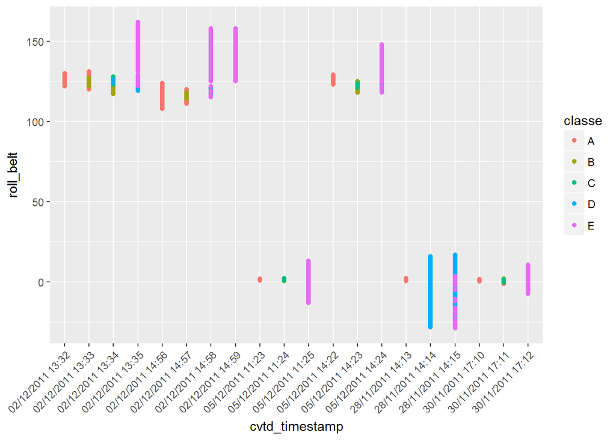

```r
#Is there an association with time and exercise?
ggplot(Trimmed_Training_Set, aes(x=cvtd_timestamp, y=roll_belt, colour=classe)) +
    geom_point() +
    theme(axis.text.x=element_text(angle=45, hjust=1))
```

Based on this graph it appears that the exercises were performed sequentially. In this case time would have a high association with exercises and should **not** be included in the model development.

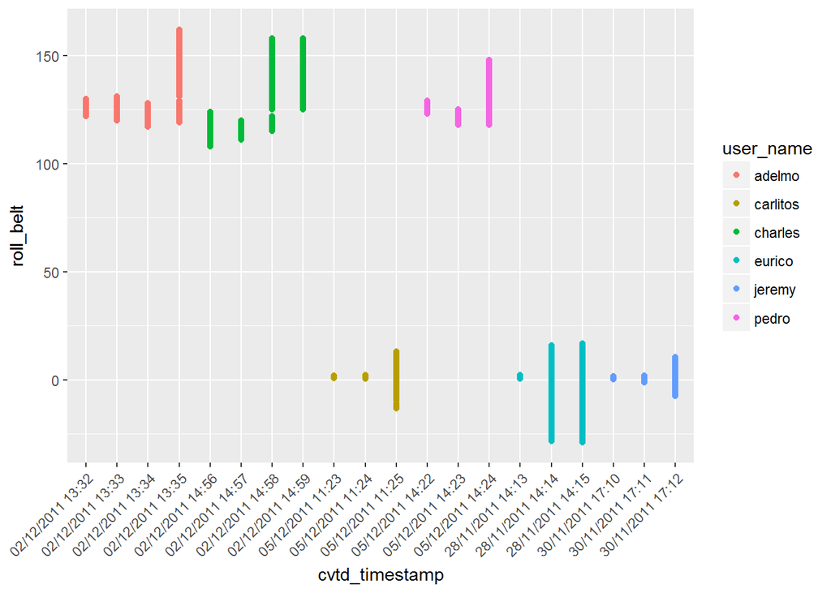

```r
#Is there an association with user and time
ggplot(Trimmed_Training_Set, aes(x=cvtd_timestamp, y=roll_belt, colour=user_name)) +
    geom_point() +
    theme(axis.text.x=element_text(angle=45, hjust=1))
```

This figure shows that time is strongly associated with user. In this case user should also be excluded from the model. The seperation between the sets of users suggests that multiple instruments may have been used during the experiment. Based on these figures I plan to remove the index, user name, time data and the data “window” columns.